# U-shaped patterns

Use `sample_growth_tb` to examine the ratio of log growth in the first year to log growth over the full two years for firms whose 2010–2012 log growth exceeds a threshold. In relation to the predictions of subexponentiality, examine whether the ratio exhibits a U-shape, with concentrations near zero and one.

## 1 Data preparation and ratio construction

```r
library(tidyverse)
library(pins)
library(hrbrthemes)
theme_set(theme_ipsum(base_size = 12, axis_title_size = 13))
board <- board_folder("../Zipf_law_board_replicate_simulation")
```

**Definition of the ratio variable**

Load `sample_growth_tb` and calculate firm age `age` as the beginning year minus establishment year `birth_year`. For records in each period, select observations with beginning-of-period sales of at least $4.0\times10^4$, beginning-of-period age of at least five, and industry codes whose first two digits are 01–61 or 68–92. Sales are measured in thousands of yen, so this lower bound corresponds to 40 million yen.

Both periods used in the ratio, 2010–2011 (`g_11_10`) and 2010–2012 (`g_12_10`), start in 2010. Define the ratio as $r_{12,10}=g_{11,10}/g_{12,10}$.

```r
sample_growth_tb <- board |> pin_read("sample_growth_tb", type = "qs2") |>
  mutate(age = as.numeric(str_c(20, str_sub(year, 6,7))) - birth_year) |>
  filter(pre_sale >= 4.0*10^4,
         str_sub(ind_class, 1,2) %in% str_pad(c(1:61, 68:92), 2, pad = 0),
         age >= 5)

ratio_tb <- sample_growth_tb |>
  pivot_wider(id_cols = id, names_from = year, values_from = growth) |>
  filter(is.finite(g_11_10), is.finite(g_12_10)) |>
  mutate(r_12_10 = g_11_10/g_12_10)
```

## 2 Ratio distributions by threshold

Set threshold values $u$ from 0.1 to 1.8 in increments of 0.1. For each threshold, select firms whose two-year growth satisfies $g_{12,10}>u$ and create a histogram after excluding observations with ratios exactly equal to zero or one. Restrict the horizontal axis to −0.3–1.3 using `xlim()`.

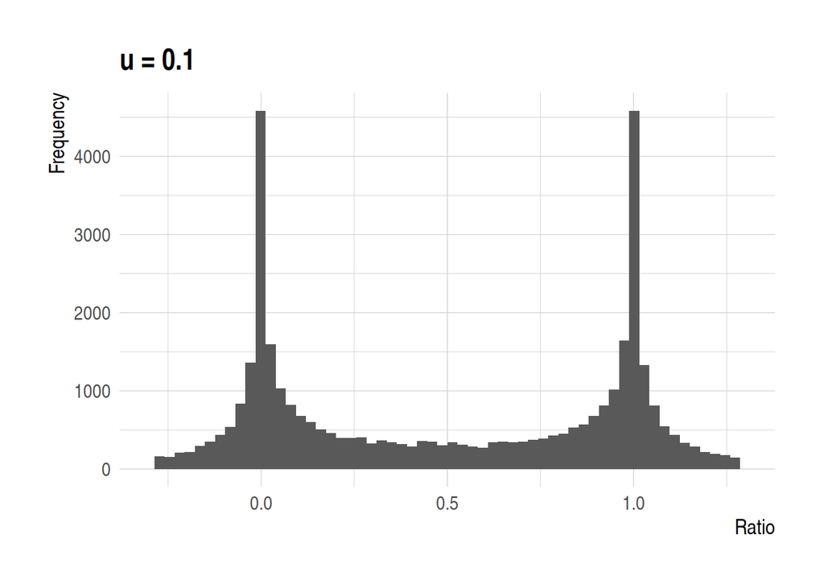

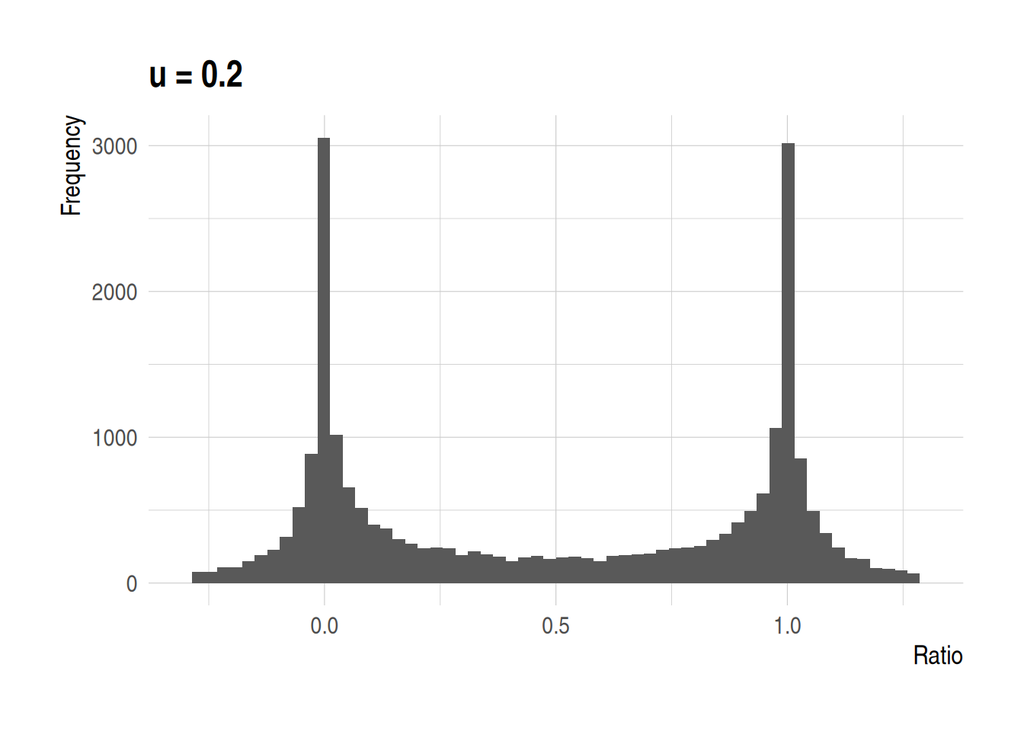

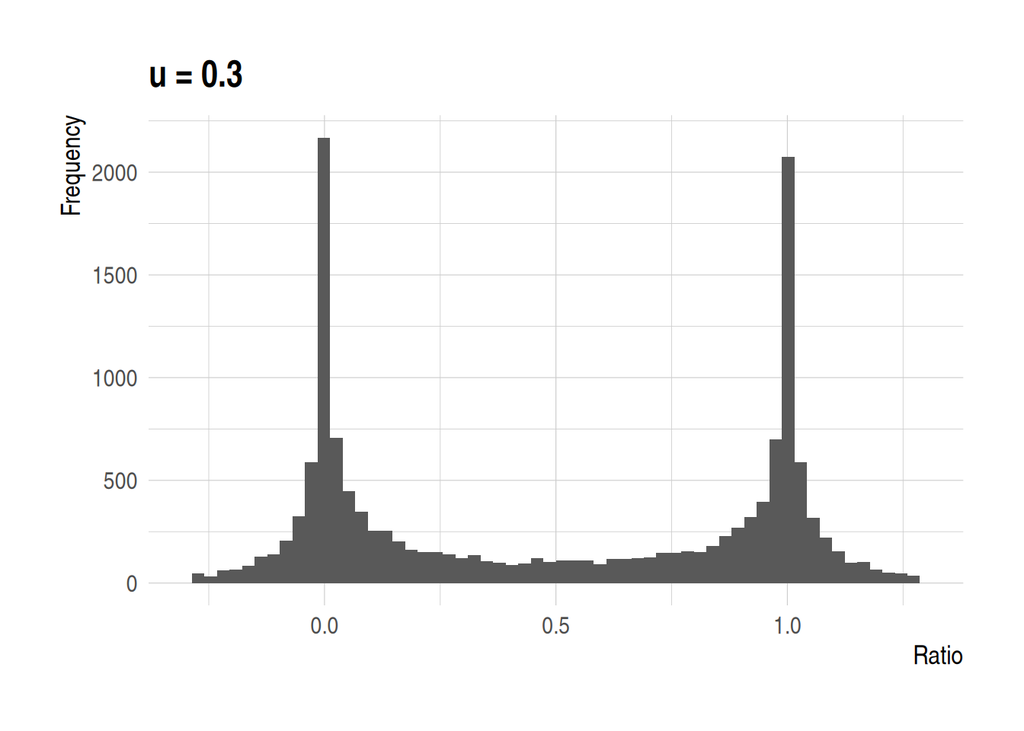

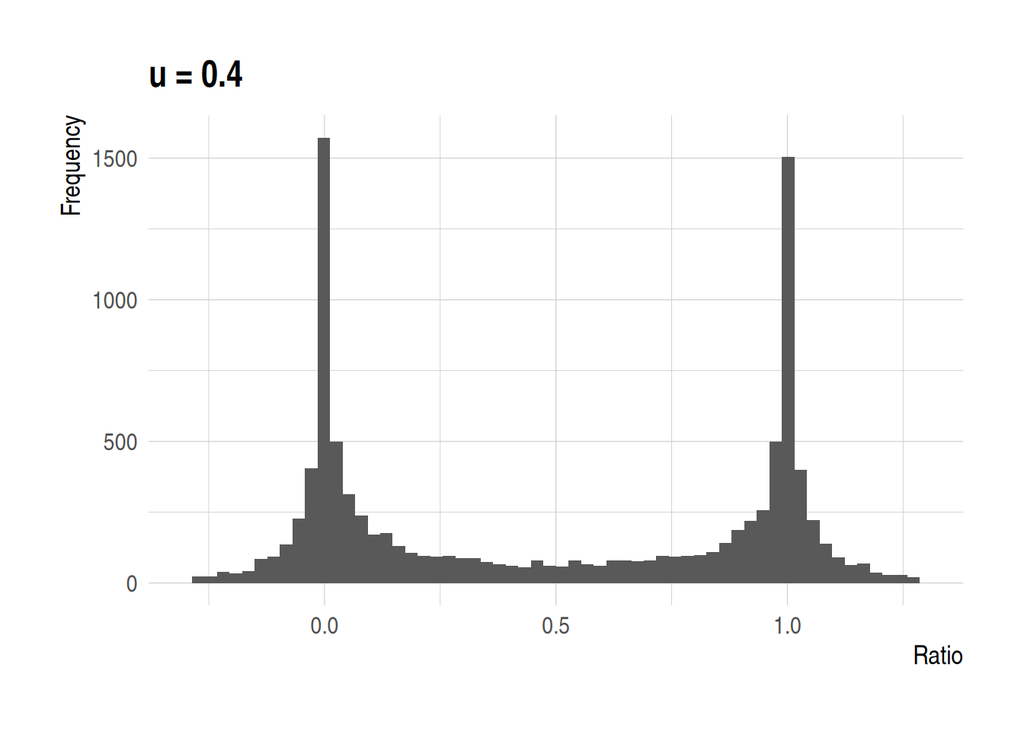

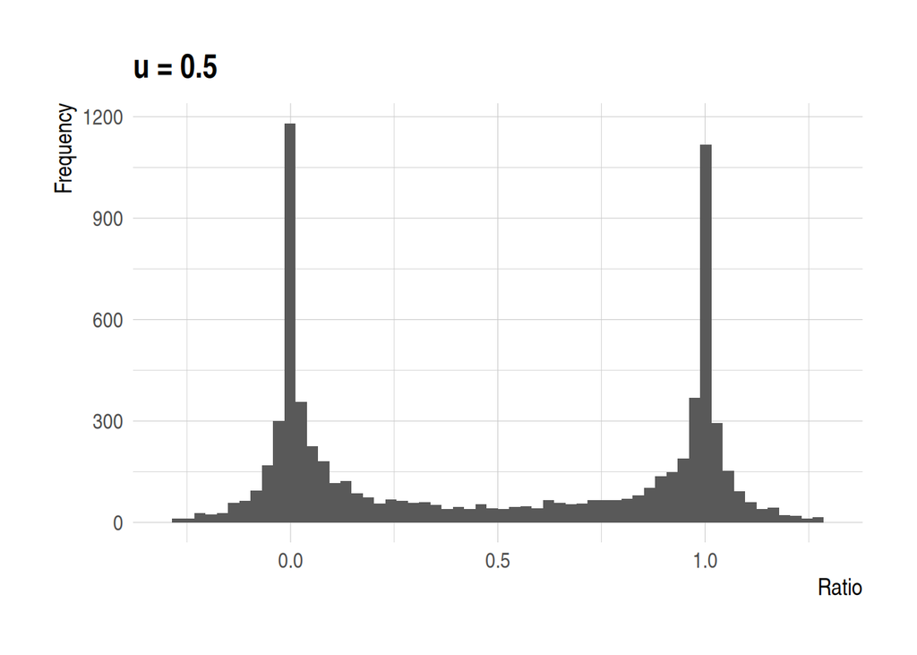

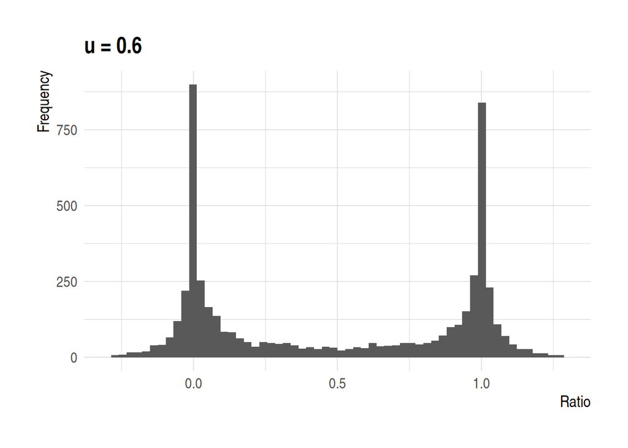

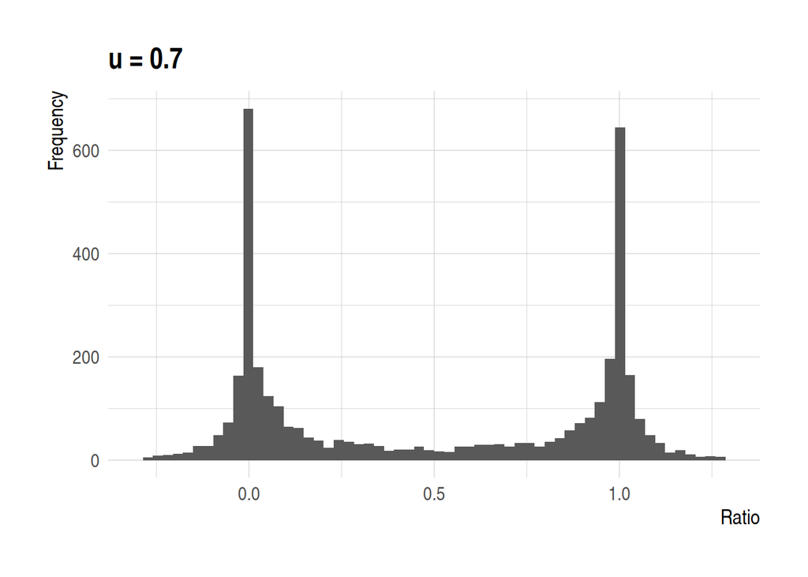

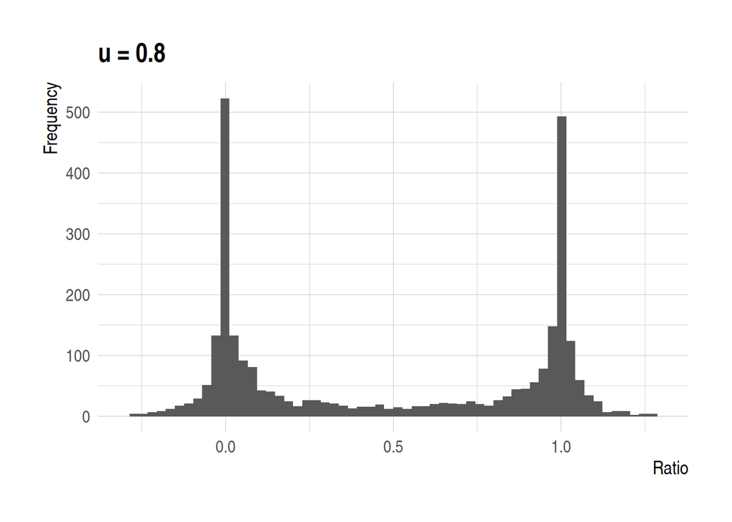

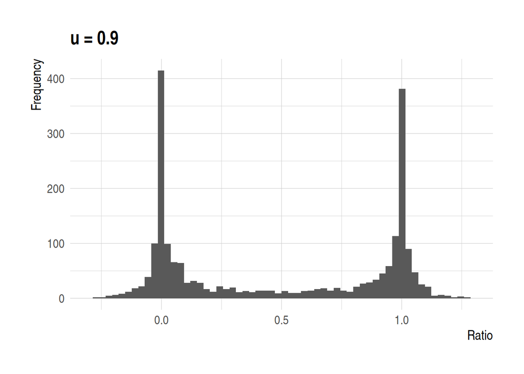

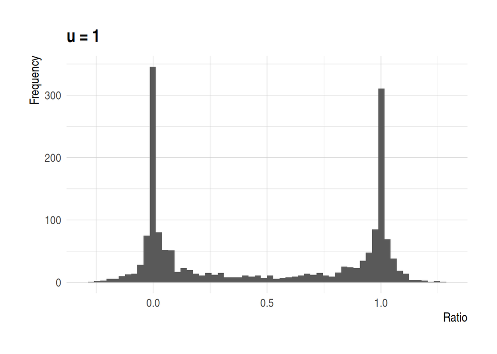

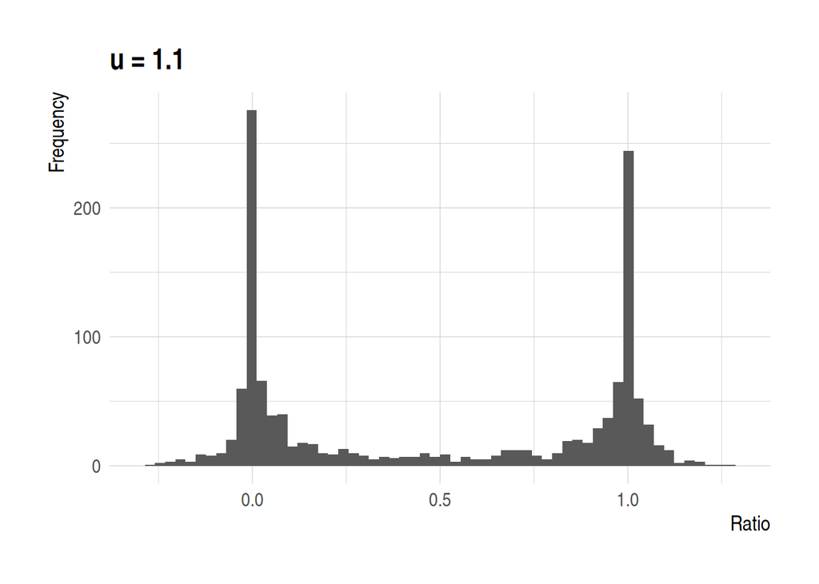

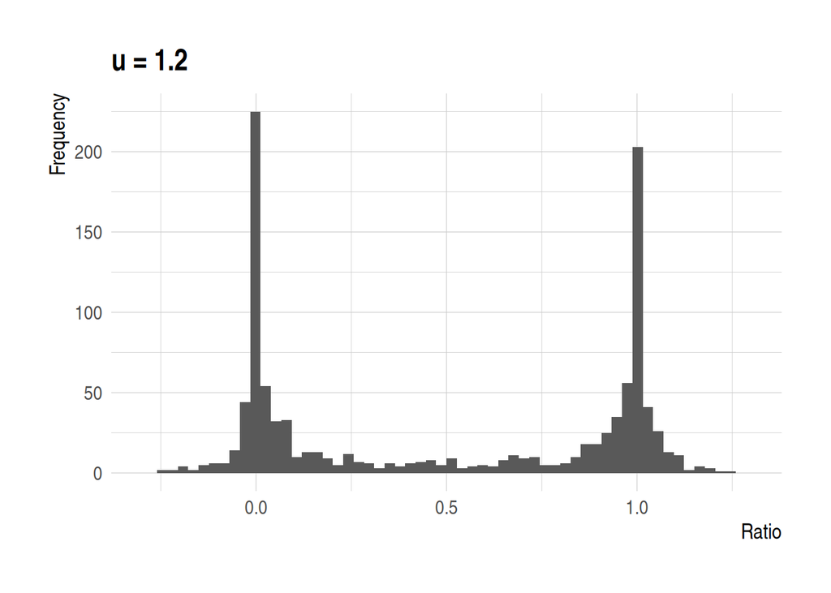

[6 more figures not shown]

```r
x_values <- seq(0.1, 1.8, by = 0.1)

plot_tb <- ratio_tb |>
  select(id, r_12_10, g_12_10) |>
  filter(r_12_10 != 0, r_12_10 != 1)

plots <- map(x_values, \(threshold) {
  plot_tb |>
    filter(g_12_10 > threshold) |>
    ggplot(aes(r_12_10)) +
      geom_histogram(bins = 60) +
      xlim(c(-0.3, 1.3)) +
      ggtitle(paste("u =", threshold)) +
      labs(x = "Ratio", y = "Frequency") +
      theme(axis.title = element_text(face = "bold"))
})

walk(plots, print)
walk2(plots, x_values, \(plot, threshold) {
  ggsave(
    filename = str_c("graph/ratio_x_", threshold, ".png"),
    plot = plot
  )
})
```